# Diabetic

### Predicting Diabetes Probability With Logistic Regression

##### Logistic regression is a statistical method used to perform prediction for categorical results, eg in this scenario, to predict if the group of patients in our dataset will develop diabetes, given their respective health information. This same method can also be used for Sales prediction, eg will customers purchase a certain product, or in Human Resources prediction, eg will employee leave the company.

##### This dataset is originally from the US National Institute of Diabetes and Digestive and Kidney Diseases. Data was obtained from kaggle.com.

##### The objective of this article is to diagnostically predict whether or not a patient has diabetes, based on certain diagnostic measurements included in the dataset. All patients here are females at least 21 years old of Native American Indian heritage.

##### The dataset consists of several medical predictor variables and one target variable, Outcome (whereby outcome = 1 indicates patient has high probability of developing diabetes and outcome = 0 indicates otherwise. Predictor variables include the number of pregnancies the patient has had, their BMI, insulin level, age, and so on.

#### Getting Started

The first step is to import libraries to be used for analysis and charting. Panda and numpy libraries are used for data analysis purposes while seaborn and matplotlib will be used for chart plotting.

```python
%matplotlib inline
import pandas as pd
import numpy as np
import seaborn as sns
import matplotlib.pyplot as plt
%config InlineBackend.figure_format = 'retina'
sns.set()
```

After importing our libraries, we will need to prepare our dataset. For this purpose, we will import data from csv file with our required dataset.

```python
df = pd.read_csv('~/Documents/1_DS_360/4_Porftolio/1_Diabetic/datasets-228-482-diabetes.csv')
```

```python
df.sample(20)
```

|  | Pregnancies | Glucose | BloodPressure | SkinThickness | Insulin | BMI | DiabetesPedigreeFunction | Age | Outcome |
| --- | --- | --- | --- | --- | --- | --- | --- | --- | --- |
| 427 | 1 | 181 | 64 | 30 | 180 | 34.1 | 0.328 | 38 | 1 |
| 129 | 0 | 105 | 84 | 0 | 0 | 27.9 | 0.741 | 62 | 1 |
| 633 | 1 | 128 | 82 | 17 | 183 | 27.5 | 0.115 | 22 | 0 |
| 761 | 9 | 170 | 74 | 31 | 0 | 44.0 | 0.403 | 43 | 1 |
| 635 | 13 | 104 | 72 | 0 | 0 | 31.2 | 0.465 | 38 | 1 |
| 273 | 1 | 71 | 78 | 50 | 45 | 33.2 | 0.422 | 21 | 0 |
| 479 | 4 | 132 | 86 | 31 | 0 | 28.0 | 0.419 | 63 | 0 |
| 457 | 5 | 86 | 68 | 28 | 71 | 30.2 | 0.364 | 24 | 0 |
| 616 | 6 | 117 | 96 | 0 | 0 | 28.7 | 0.157 | 30 | 0 |
| 400 | 4 | 95 | 64 | 0 | 0 | 32.0 | 0.161 | 31 | 1 |
| 698 | 4 | 127 | 88 | 11 | 155 | 34.5 | 0.598 | 28 | 0 |
| 256 | 3 | 111 | 56 | 39 | 0 | 30.1 | 0.557 | 30 | 0 |
| 732 | 2 | 174 | 88 | 37 | 120 | 44.5 | 0.646 | 24 | 1 |
| 464 | 10 | 115 | 98 | 0 | 0 | 24.0 | 1.022 | 34 | 0 |
| 331 | 2 | 87 | 58 | 16 | 52 | 32.7 | 0.166 | 25 | 0 |
| 515 | 3 | 163 | 70 | 18 | 105 | 31.6 | 0.268 | 28 | 1 |
| 429 | 1 | 95 | 82 | 25 | 180 | 35.0 | 0.233 | 43 | 1 |
| 317 | 3 | 182 | 74 | 0 | 0 | 30.5 | 0.345 | 29 | 1 |
| 741 | 3 | 102 | 44 | 20 | 94 | 30.8 | 0.400 | 26 | 0 |
| 52 | 5 | 88 | 66 | 21 | 23 | 24.4 | 0.342 | 30 | 0 |

Next, we can perform general checks on the data in csv file. There are 768 rows of data in our dataset, comprising integers and numerical data with decimals. No null data were noted in all rows and columns (ie no missing data in our dataset).

```python
df.info()
```

```
<class 'pandas.core.frame.DataFrame'>
RangeIndex: 768 entries, 0 to 767
Data columns (total 9 columns):
 #   Column                    Non-Null Count  Dtype
---  ------                    --------------  -----
 0   Pregnancies               768 non-null    int64
 1   Glucose                   768 non-null    int64
 2   BloodPressure             768 non-null    int64
 3   SkinThickness             768 non-null    int64
 4   Insulin                   768 non-null    int64
 5   BMI                       768 non-null    float64
 6   DiabetesPedigreeFunction  768 non-null    float64
 7   Age                       768 non-null    int64
 8   Outcome                   768 non-null    int64
dtypes: float64(2), int64(7)
memory usage: 54.1 KB
```

The standard deviation and quartile ranges let us know how dispersed the distribution of the data within each column is as comparetd to the average. A low standard deviation means that most of the numbers are close to the average, while a high standard deviation means that the numbers are more spread out.

```python
df.describe()
```

|  | Pregnancies | Glucose | BloodPressure | SkinThickness | Insulin | BMI | DiabetesPedigreeFunction | Age | Outcome |
| --- | --- | --- | --- | --- | --- | --- | --- | --- | --- |
| count | 768.000000 | 768.000000 | 768.000000 | 768.000000 | 768.000000 | 768.000000 | 768.000000 | 768.000000 | 768.000000 |
| mean | 3.845052 | 120.894531 | 69.105469 | 20.536458 | 79.799479 | 31.992578 | 0.471876 | 33.240885 | 0.348958 |
| std | 3.369578 | 31.972618 | 19.355807 | 15.952218 | 115.244002 | 7.884160 | 0.331329 | 11.760232 | 0.476951 |
| min | 0.000000 | 0.000000 | 0.000000 | 0.000000 | 0.000000 | 0.000000 | 0.078000 | 21.000000 | 0.000000 |
| 25% | 1.000000 | 99.000000 | 62.000000 | 0.000000 | 0.000000 | 27.300000 | 0.243750 | 24.000000 | 0.000000 |
| 50% | 3.000000 | 117.000000 | 72.000000 | 23.000000 | 30.500000 | 32.000000 | 0.372500 | 29.000000 | 0.000000 |
| 75% | 6.000000 | 140.250000 | 80.000000 | 32.000000 | 127.250000 | 36.600000 | 0.626250 | 41.000000 | 1.000000 |
| max | 17.000000 | 199.000000 | 122.000000 | 99.000000 | 846.000000 | 67.100000 | 2.420000 | 81.000000 | 1.000000 |

### Data Analysis and Data Plots

#### Correlation

To further understand the relationship between each of the variables in our data, an important step is to find out the correlation between the variables. This will help us understand the impact that each variable has on one another.

We will do this by plotting a heatmap using seaborn and matplotlib libraries imported earlier. The relationship between each variables can be observed (whether they are positively or inversely related to each other) and the degree of impact it has on one another.

Observations : 1) Age and pregnancies are highly correlated. This is very relevant in today's world as more women are bearing children at much later stages of their lives.  
2) Blood glucose level is a high determinant for diabetes.

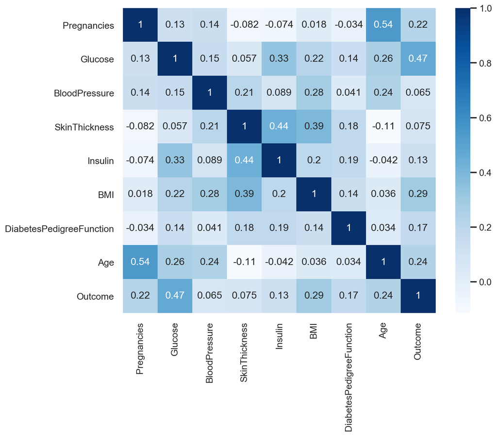

```python
sns.set(rc={'figure.figsize':(10,8)})
sns.set_context("talk", font_scale=0.8)
sns.heatmap(df.corr(), cmap='Blues', annot=True)
```

#### Number of Diabetic Patients

Next, we will plot a graph to look at the number of diabetic patients in our current dataset.  
Observations : 268 patients diagnosed with diabetes while 500 diagnosed without.

[output not shown]

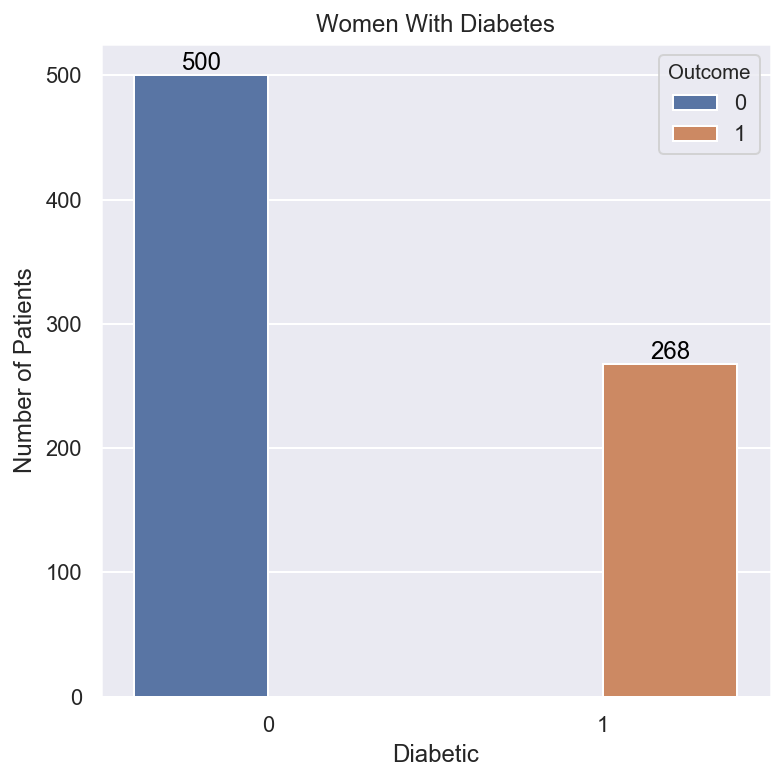

```python
sns.set(rc={'figure.figsize':(6,6)})

ax = sns.countplot(df['Outcome'], hue="Outcome", data = df)
loc, labels = plt.xticks()
ax.set_xticklabels(labels);

for p in ax.patches:
    ax.text(p.get_x() + p.get_width()/2., p.get_height(), '{0:.0f}'.format(p.get_height()),
        fontsize=12, color='black', ha='center', va='bottom')


plt.title("Women With Diabetes")
plt.xlabel('Diabetic')
plt.ylabel('Number of Patients')
```

#### Age Analysis

Let's look at the age of all women. We plot a graph to analyse the number of diabetic patients by age in our current dataset.  
Observations : 1) High number of diabetic patients from mid-twenties to early-forties.  
2) Non-diabetic patients are in early twenties. This could be due to non-pregnancies in this age group (as noted earlier, age and pregnancies have a positive relationship).

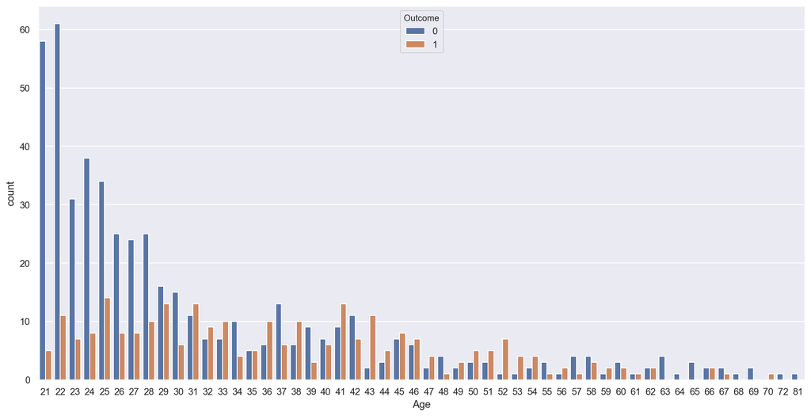

```python
sns.set(rc={'figure.figsize':(16,8)})
sns.countplot(x="Age", hue="Outcome", data=df)
```

For subsequent analyses, we will look at data for diabetic patients only. Filter dataset to diabetic patients.

```python
newdf = df[(df.Outcome == 1)]
newdf
```

|  | Pregnancies | Glucose | BloodPressure | SkinThickness | Insulin | BMI | DiabetesPedigreeFunction | Age | Outcome |
| --- | --- | --- | --- | --- | --- | --- | --- | --- | --- |
| 0 | 6 | 148 | 72 | 35 | 0 | 33.6 | 0.627 | 50 | 1 |
| 2 | 8 | 183 | 64 | 0 | 0 | 23.3 | 0.672 | 32 | 1 |
| 4 | 0 | 137 | 40 | 35 | 168 | 43.1 | 2.288 | 33 | 1 |
| 6 | 3 | 78 | 50 | 32 | 88 | 31.0 | 0.248 | 26 | 1 |
| 8 | 2 | 197 | 70 | 45 | 543 | 30.5 | 0.158 | 53 | 1 |
| ... | ... | ... | ... | ... | ... | ... | ... | ... | ... |
| 755 | 1 | 128 | 88 | 39 | 110 | 36.5 | 1.057 | 37 | 1 |
| 757 | 0 | 123 | 72 | 0 | 0 | 36.3 | 0.258 | 52 | 1 |
| 759 | 6 | 190 | 92 | 0 | 0 | 35.5 | 0.278 | 66 | 1 |
| 761 | 9 | 170 | 74 | 31 | 0 | 44.0 | 0.403 | 43 | 1 |
| 766 | 1 | 126 | 60 | 0 | 0 | 30.1 | 0.349 | 47 | 1 |

268 rows × 9 columns

Next, we plot a scatterplot to analyse relationship between pregnant women with diabetes and their age.  
Observations : Similar to observation above, more women are pregnant between mid-twenties and early-forties have been diagnosed with diabetes.

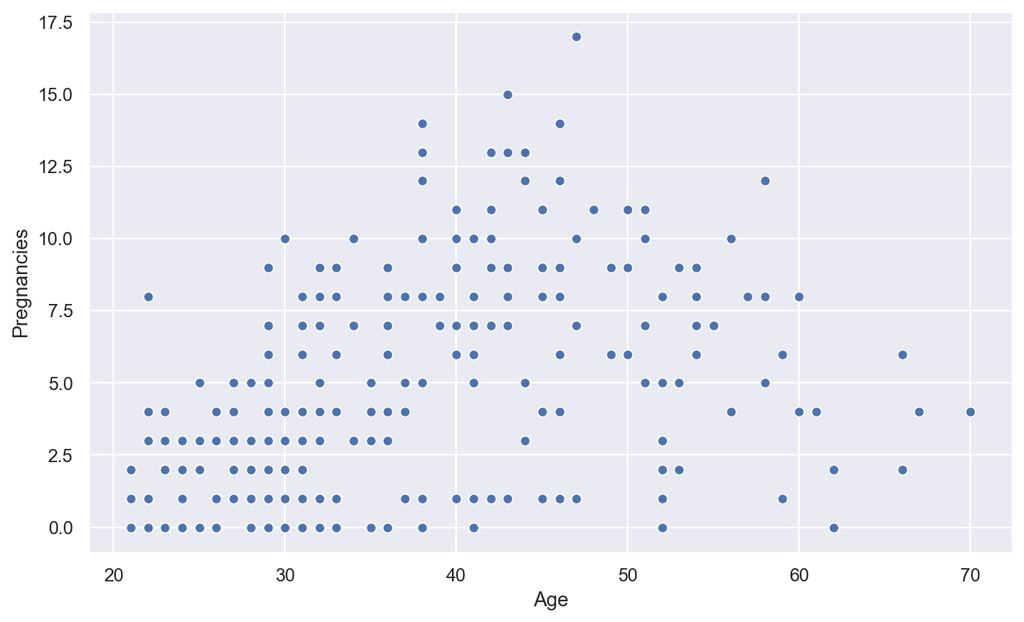

```python
sns.set(rc={'figure.figsize':(10,6)})
sns.scatterplot(x = 'Age', y = 'Pregnancies', data = newdf)
```

Let's look at the age of diabetic patients. Plot a histogram based on patient's age.  
Observations : Highest number of patients are in late the twenties age group.

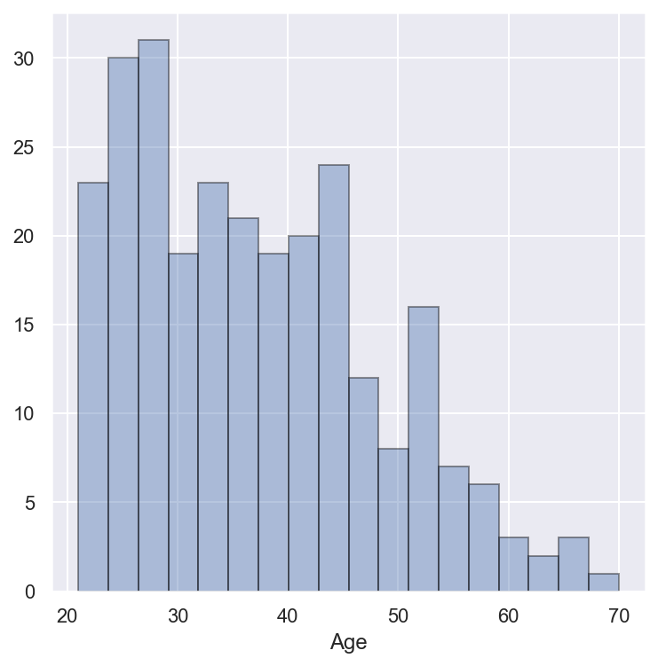

```python
sns.set(rc={'figure.figsize':(6,6)})
sns.distplot(newdf['Age'], hist=True, kde=False, bins=int(180/10), hist_kws={'edgecolor':'black'})
```

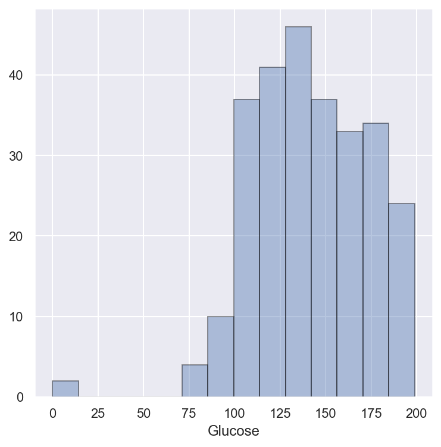

```python
sns.distplot(newdf['Glucose'], norm_hist=False, kde=False, hist_kws={'edgecolor':'black'})
```

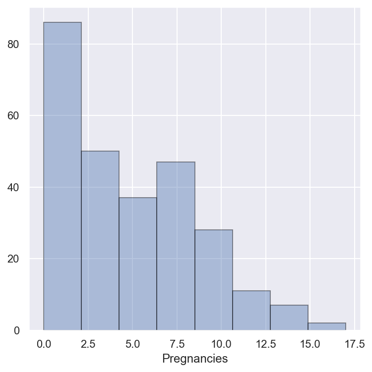

```python
sns.distplot(newdf['Pregnancies'], bins=int(500/60), norm_hist=False, kde=False, hist_kws={'edgecolor':'black'})
```

The analyses above have given us an idea on the relationship between the dataset and their correlation to being diabetic. However, to more accurately predict the relationship of our variables, we can make use of logistic regression, which is useful for predicting outcomes of binary nature eg yes or no results.

### Logistic Regression

Let's run logistic regression model and check which factors influence diabetic probability. We will use the scikit-learn library for this purpose. Use model from scikit-learn to check model prediction accuracy. 1) Age & Pregnancies

```python
from sklearn.linear_model import LogisticRegression
columns = ['Age','Pregnancies']
X = df[columns]
y = df['Outcome']

from sklearn.metrics import accuracy_score
logmodel = LogisticRegression()
logmodel.fit(X,y)
predictions = logmodel.predict(X)
accuracy_score(y,predictions)
```

```
0.6627604166666666
```

2) Insulin & Glucose

```python
from sklearn.linear_model import LogisticRegression
columns = ['Insulin','Glucose']
X = df[columns]
y = df['Outcome']

from sklearn.metrics import accuracy_score
logmodel = LogisticRegression()
logmodel.fit(X,y)
predictions = logmodel.predict(X)
accuracy_score(y,predictions)
```

```
0.74609375
```

3) Skin Thickness & Glucose

```python
from sklearn.linear_model import LogisticRegression
columns = ['SkinThickness','Glucose']
X = df[columns]
y = df['Outcome']

from sklearn.metrics import accuracy_score
logmodel = LogisticRegression()
logmodel.fit(X,y)
predictions = logmodel.predict(X)
accuracy_score(y,predictions)
```

```
0.7395833333333334
```

4) Age & Pregnancies

```python
from sklearn.linear_model import LogisticRegression
columns = ['Age','Pregnancies']
X = df[columns]
y = df['Outcome']

from sklearn.metrics import accuracy_score
logmodel = LogisticRegression()
logmodel.fit(X,y)
predictions = logmodel.predict(X)
accuracy_score(y,predictions)
```

```
0.6627604166666666
```

### Prediction

```python
predict = pd.read_csv('~/Documents/1_DS_360/4_Porftolio/1_Diabetic/datasets_diabetes_prediction.csv')
X_predict = predict[columns]
predictions = logmodel.predict(X_predict)
predict['Diabetic'] = predictions
predict

is_1=predict['Diabetic']==1
predict_1=predict[is_1]
predict_1
```

|  | ID | Pregnancies | Glucose | BloodPressure | SkinThickness | Insulin | BMI | DiabetesPedigreeFunction | Age | Diabetic |
| --- | --- | --- | --- | --- | --- | --- | --- | --- | --- | --- |
| 0 | 1 | 6 | 148 | 72 | 35 | 0 | 33.6 | 0.627 | 50 | 1 |
| 9 | 10 | 8 | 125 | 96 | 0 | 0 | 0.0 | 0.232 | 54 | 1 |
| 12 | 13 | 10 | 139 | 80 | 0 | 0 | 27.1 | 1.441 | 57 | 1 |
| 21 | 22 | 8 | 99 | 84 | 0 | 0 | 35.4 | 0.388 | 50 | 1 |
| 24 | 25 | 11 | 143 | 94 | 33 | 146 | 36.6 | 0.254 | 51 | 1 |
| ... | ... | ... | ... | ... | ... | ... | ... | ... | ... | ... |
| 749 | 750 | 6 | 162 | 62 | 0 | 0 | 24.3 | 0.178 | 50 | 1 |
| 754 | 755 | 8 | 154 | 78 | 32 | 0 | 32.4 | 0.443 | 45 | 1 |
| 759 | 760 | 6 | 190 | 92 | 0 | 0 | 35.5 | 0.278 | 66 | 1 |
| 761 | 762 | 9 | 170 | 74 | 31 | 0 | 44.0 | 0.403 | 43 | 1 |
| 763 | 764 | 10 | 101 | 76 | 48 | 180 | 32.9 | 0.171 | 63 | 1 |

121 rows × 10 columns

The table above shows list of patients highly likely to develop diabetes (only a sample of the final results are shown here as the list is too long).